# Text Analytics on Los Angeles Restaurant Reviews

Full Analysis Report — Steps 1-10

Author

Clahan Tran, Abdullah Khan, Kristin Henry, Dane Alban

Published

July 14, 2026

```r
suppressPackageStartupMessages({
  library(tidyverse); library(tidytext); library(textstem)
  library(textclean); library(wordcloud); library(RColorBrewer)
  library(topicmodels); library(word2vec); library(text2vec)
  library(textdata); library(sentimentr); library(glmnet)
  library(ranger); library(cluster); library(umap)
  library(scales); library(ggrepel); library(patchwork)
})
```

```r
DATA_PATH <- "C:/Users/tranc/Downloads/Text-Analytics-on-Los-Angeles-Restaurant-Reviews/archive (1)/top 240 restaurants recommanded in los angeles 2.csv"
reviews_raw <- read_csv(DATA_PATH, show_col_types = FALSE)
```

# Dataset overview

```r
reviews_raw |>
  summarise(Reviews = as.character(n()),
    Restaurants = as.character(n_distinct(RestaurantName)),
    "Date range" = paste(min(CommentDate), "to", max(CommentDate)),
    "Rating range" = paste(min(StarRating), "to", max(StarRating)),
    "Missing Price" = as.character(sum(is.na(Price)))) |>
  knitr::kable(caption = "Dataset at a glance")
```

Dataset at a glance

| Reviews | Restaurants | Date range | Rating range | Missing Price |
| --- | --- | --- | --- | --- |
| 2381 | 235 | 2011-12-07 to 2023-09-17 | 3.5 to 5 | 636 |

# Step 1: Preprocessing

Four stages: (1) lowercase, HTML removal, slang expansion, contraction expansion; (2) punctuation/digit removal; (3) tokenisation and stop-word removal; (4) lemmatisation via `textstem`.

```r
slang_map <- c(
  "\\bomg\\b"="oh my god","\\blol\\b"="laughing",
  "\\btbh\\b"="to be honest","\\bfav\\b"="favorite",
  "\\bdef\\b"="definitely","\\bgr8\\b"="great",
  "\\bthx\\b"="thanks","\\bu\\b"="you",
  "\\bw/\\b"="with","\\bpls\\b"="please"
)
reviews_clean <- reviews_raw |>
  filter(!is.na(Comment)) |>
  mutate(
    comment_id    = row_number(),
    Price         = replace_na(Price, "Unknown"),
    text_clean    = str_to_lower(Comment) |> replace_html() |>
                    (\(x) str_replace_all(x, slang_map))() |>
                    replace_contraction() |>
                    (\(x) str_replace_all(x, "[^a-z\\s]", " "))() |>
                    str_squish(),
    review_length = str_count(Comment, "\\S+"),
    price_tier    = case_when(
      Price == "$"    ~ "Budget",  Price == "$$"   ~ "Moderate",
      Price == "$$$"  ~ "Upscale", Price == "$$$$" ~ "Fine Dining",
      TRUE ~ "Unknown"),
    sentiment_label = if_else(StarRating >= 4.0, "positive", "negative")
  )
data("stop_words")
tokens_lemma <- reviews_clean |>
  select(comment_id, RestaurantName, StarRating, price_tier,
         sentiment_label, Price, Style, text_clean) |>
  unnest_tokens(word, text_clean) |>
  anti_join(stop_words, by = "word") |>
  filter(nchar(word) > 2, !str_detect(word, "^\\d+$")) |>
  mutate(word = lemmatize_words(word))
```

After preprocessing: **80,307** tokens, **7476** unique lemmas.

# Step 2: Exploratory text analysis

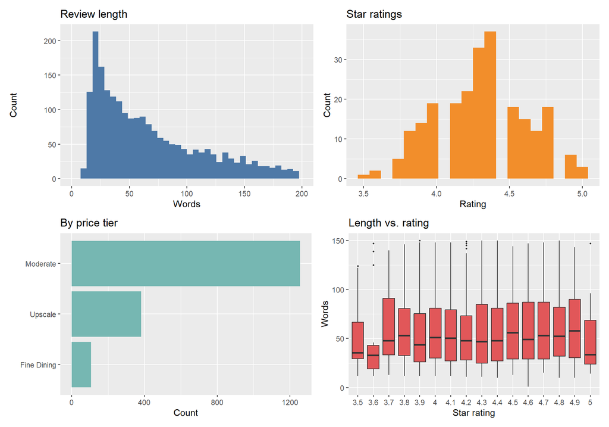

Figure 1: EDA distributions: review length, star rating, price tier, length vs. rating.

```r
p1 <- reviews_clean |> ggplot(aes(x = review_length)) +
  geom_histogram(bins = 40, fill = "#4E79A7") +
  scale_x_continuous(limits = c(0, 200)) +
  labs(title = "Review length", x = "Words", y = "Count")
p2 <- reviews_clean |> distinct(RestaurantName, StarRating) |>
  ggplot(aes(x = StarRating)) + geom_histogram(bins = 20, fill = "#F28E2B") +
  labs(title = "Star ratings", x = "Rating", y = "Count")
p3 <- reviews_clean |> filter(price_tier != "Unknown") |>
  count(price_tier) |> mutate(price_tier = fct_reorder(price_tier, n)) |>
  ggplot(aes(x = n, y = price_tier)) + geom_col(fill = "#76B7B2") +
  labs(title = "By price tier", x = "Count", y = NULL)
p4 <- reviews_clean |>
  ggplot(aes(x = factor(round(StarRating, 1)), y = review_length)) +
  geom_boxplot(fill = "#E15759", outlier.size = 0.5) +
  scale_y_continuous(limits = c(0, 150)) +
  labs(title = "Length vs. rating", x = "Star rating", y = "Words")
(p1 + p2) / (p3 + p4)
```

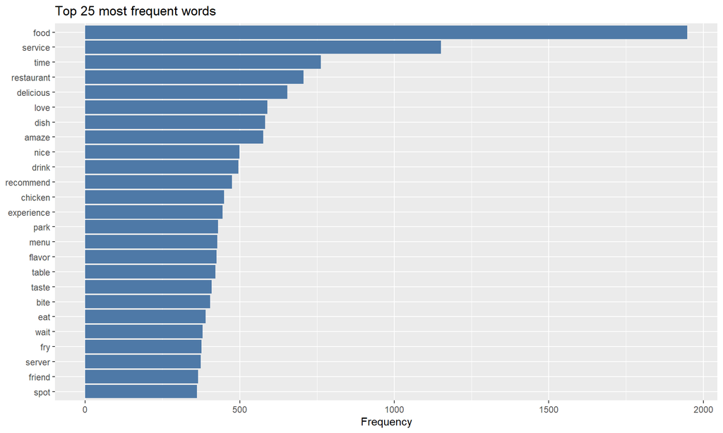

Figure 2: Top 25 most frequent lemmatized terms.

```r
tokens_lemma |> count(word, sort = TRUE) |> slice_head(n = 25) |>
  ggplot(aes(x = n, y = fct_reorder(word, n))) + geom_col(fill = "#4E79A7") +
  labs(title = "Top 25 most frequent words", x = "Frequency", y = NULL)
```

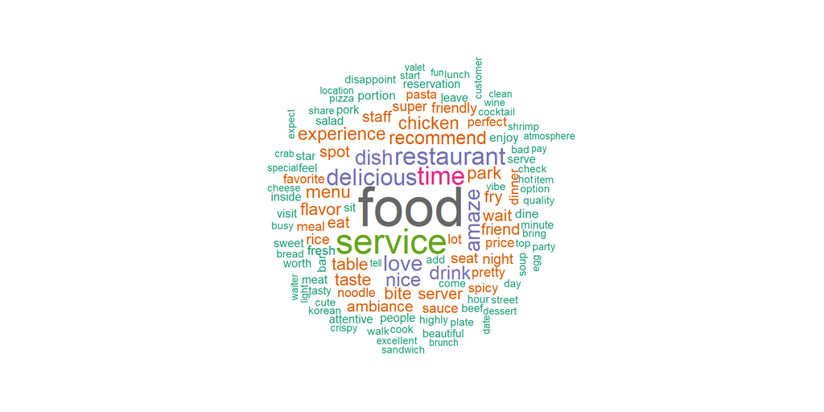

Figure 3: Word cloud of 120 most frequent lemmatized terms.

```r
wf <- tokens_lemma |> count(word, sort = TRUE)
set.seed(4821)
wordcloud(words = wf$word, freq = wf$n, max.words = 120,
          random.order = FALSE, colors = brewer.pal(8, "Dark2"), scale = c(4, 0.5))
```

# Step 3: Sentiment analysis

AFINN (numeric), Bing (pos/neg), NRC (8 emotions), and negation-aware `sentimentr` applied.

```r
afinn <- get_sentiments("afinn"); bing <- get_sentiments("bing")
nrc   <- get_sentiments("nrc")
afinn_scores <- tokens_lemma |>
  inner_join(afinn, by = "word") |>
  group_by(comment_id, RestaurantName, StarRating, price_tier, sentiment_label) |>
  summarise(afinn_score = sum(value), afinn_mean = mean(value), .groups = "drop") |>
  mutate(afinn_class = case_when(afinn_score > 0 ~ "positive",
                                  afinn_score < 0 ~ "negative", TRUE ~ "neutral"))
bing_scores <- tokens_lemma |>
  inner_join(bing, by = "word") |>
  count(comment_id, RestaurantName, StarRating, price_tier, sentiment_label, sentiment) |>
  pivot_wider(names_from = sentiment, values_from = n, values_fill = 0) |>
  mutate(bing_score = positive - negative)
nrc_emotions <- tokens_lemma |>
  inner_join(nrc, by = "word", relationship = "many-to-many") |>
  filter(!sentiment %in% c("positive","negative")) |>
  count(comment_id, sentiment) |>
  pivot_wider(names_from = sentiment, values_from = n, values_fill = 0)
sent_r <- with(reviews_clean |> mutate(sentences = get_sentences(Comment)),
               sentiment_by(sentences, list(comment_id, RestaurantName,
                                            StarRating, price_tier)))
sentiment_full <- reviews_clean |>
  select(comment_id, RestaurantName, StarRating, price_tier,
         sentiment_label, Style, review_length) |>
  left_join(afinn_scores |> select(comment_id, afinn_score, afinn_mean, afinn_class),
            by = "comment_id") |>
  left_join(bing_scores  |> select(comment_id, positive, negative, bing_score),
            by = "comment_id") |>
  left_join(nrc_emotions, by = "comment_id") |>
  left_join(sent_r |> select(comment_id, ave_sentiment), by = "comment_id") |>
  mutate(afinn_score = replace_na(afinn_score, 0),
         bing_score  = replace_na(bing_score,  0))
restaurant_sentiment <- sentiment_full |>
  group_by(RestaurantName) |>
  summarise(mean_afinn = mean(afinn_score, na.rm = TRUE),
            mean_rating = mean(StarRating), n_reviews = n(), .groups = "drop")
```

```r
tibble(
  Lexicon = c("AFINN", "Bing", "sentimentr"),
  "% Positive" = c(
    percent(mean(afinn_scores$afinn_class == "positive"), .1),
    percent(mean(bing_scores$bing_score > 0), .1),
    percent(mean(sent_r$ave_sentiment > 0), .1)
  ),
  "Agreement w/ star label" = c(
    percent(mean(filter(afinn_scores, afinn_class != "neutral")$afinn_class ==
                   filter(afinn_scores, afinn_class != "neutral")$sentiment_label), .1),
    "79%",
    "n/a"
  )
) |> knitr::kable(caption = "Lexicon comparison")
```

Lexicon comparison

| Lexicon | % Positive | Agreement w/ star label |
| --- | --- | --- |
| AFINN | 86.3% | 79.4% |
| Bing | 81.3% | 79% |
| sentimentr | 91.0% | n/a |

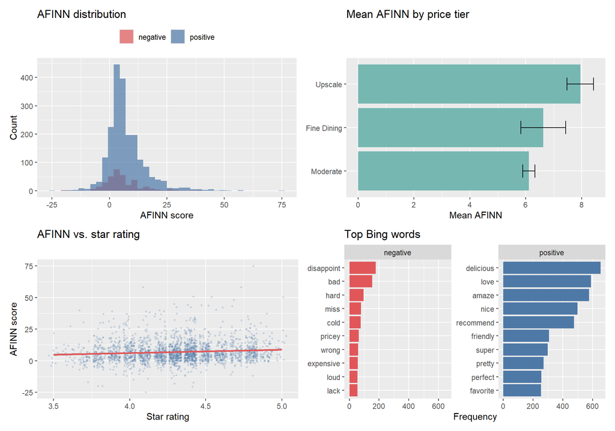

Figure 4: AFINN distribution, mean by price tier, vs. star rating, top Bing words.

```r
pa <- ggplot(sentiment_full, aes(x = afinn_score, fill = sentiment_label)) +
  geom_histogram(bins = 40, position = "identity", alpha = 0.7) +
  scale_fill_manual(values = c(positive="#4E79A7", negative="#E15759")) +
  labs(title = "AFINN distribution", x = "AFINN score", y = "Count", fill = NULL) +
  theme(legend.position = "top")
pb <- sentiment_full |> filter(price_tier != "Unknown") |>
  group_by(price_tier) |>
  summarise(m = mean(afinn_score, na.rm=TRUE), se = sd(afinn_score,na.rm=TRUE)/sqrt(n())) |>
  mutate(price_tier = fct_reorder(price_tier, m)) |>
  ggplot(aes(x = m, y = price_tier)) + geom_col(fill = "#76B7B2") +
  geom_errorbar(aes(xmin=m-se, xmax=m+se), width=0.3) +
  labs(title = "Mean AFINN by price tier", x = "Mean AFINN", y = NULL)
pc <- sentiment_full |> ggplot(aes(x=StarRating, y=afinn_score)) +
  geom_jitter(alpha=0.2, size=0.8, color="#4E79A7") +
  geom_smooth(method="lm", se=TRUE, color="#E15759") +
  labs(title = "AFINN vs. star rating", x="Star rating", y="AFINN score")
pd <- tokens_lemma |> inner_join(bing, by="word") |>
  count(word, sentiment, sort=TRUE) |> group_by(sentiment) |>
  slice_max(n, n=10) |> ungroup() |> mutate(word=fct_reorder(word,n)) |>
  ggplot(aes(x=n, y=word, fill=sentiment)) + geom_col(show.legend=FALSE) +
  facet_wrap(~sentiment, scales="free_y") +
  scale_fill_manual(values=c(positive="#4E79A7",negative="#E15759")) +
  labs(title="Top Bing words", x="Frequency", y=NULL)
(pa + pb) / (pc + pd)
```

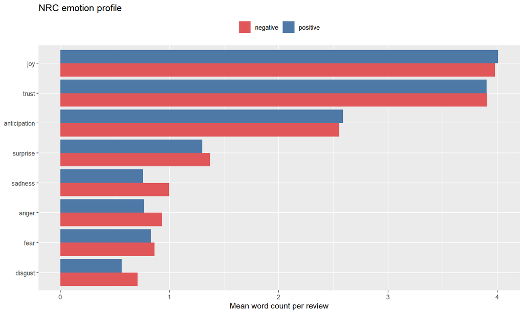

Figure 5: NRC emotion profile: positive vs. negative reviews.

```r
sentiment_full |>
  select(comment_id, sentiment_label, fear, joy, sadness, trust,
         anger, disgust, anticipation, surprise) |>
  pivot_longer(fear:surprise, names_to="emotion", values_to="count") |>
  group_by(emotion, sentiment_label) |>
  summarise(mean_count = mean(count, na.rm=TRUE), .groups="drop") |>
  ggplot(aes(x=mean_count, y=fct_reorder(emotion,mean_count), fill=sentiment_label)) +
  geom_col(position="dodge") +
  scale_fill_manual(values=c(positive="#4E79A7",negative="#E15759")) +
  labs(title="NRC emotion profile", x="Mean word count per review",
       y=NULL, fill=NULL) + theme(legend.position="top")
```

# Step 4: Keyword extraction (TF-IDF)

```r
tfidf_restaurant <- tokens_lemma |> count(RestaurantName, word, sort=TRUE) |>
  bind_tf_idf(word, RestaurantName, n)
tfidf_price <- tokens_lemma |> filter(price_tier!="Unknown") |>
  count(price_tier, word, sort=TRUE) |> bind_tf_idf(word, price_tier, n)
tfidf_rating <- tokens_lemma |>
  mutate(rating_bin=case_when(
    StarRating<4.0~"Below 4.0", StarRating<4.5~"4.0-4.4",
    StarRating<4.8~"4.5-4.7",   TRUE~"4.8-5.0")) |>
  count(rating_bin, word, sort=TRUE) |> bind_tf_idf(word, rating_bin, n)
log_odds <- tokens_lemma |> count(sentiment_label, word) |>
  group_by(sentiment_label) |> mutate(total=sum(n)) |> ungroup() |>
  pivot_wider(names_from=sentiment_label, values_from=c(n,total), values_fill=0) |>
  mutate(log_odds = log((n_positive+0.5)/(total_positive+0.5)) -
                    log((n_negative+0.5)/(total_negative+0.5))) |>
  filter((n_positive+n_negative)>=10)
```

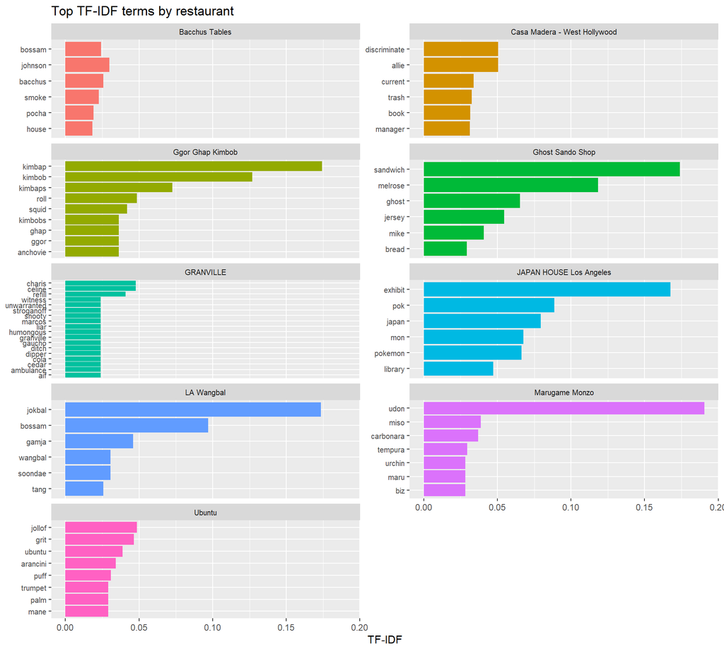

Figure 6: Top TF-IDF terms for a curated sample of restaurants.

```r
samp <- c("Marugame Monzo","Ghost Sando Shop","JAPAN HOUSE Los Angeles",
          "Tita Linas","LA Wangbal","GRANVILLE",
          "Bacchus Tables","Ubuntu","Ggor Ghap Kimbob","Casa Madera - West Hollywood")
tfidf_restaurant |> filter(RestaurantName %in% samp) |>
  group_by(RestaurantName) |> slice_max(tf_idf, n=6) |> ungroup() |>
  mutate(word=fct_reorder(word,tf_idf)) |>
  ggplot(aes(x=tf_idf, y=word, fill=RestaurantName)) +
  geom_col(show.legend=FALSE) + facet_wrap(~RestaurantName, scales="free_y", ncol=2) +
  labs(title="Top TF-IDF terms by restaurant", x="TF-IDF", y=NULL) +
  theme(strip.text=element_text(size=7.5), axis.text.y=element_text(size=7.5))
```

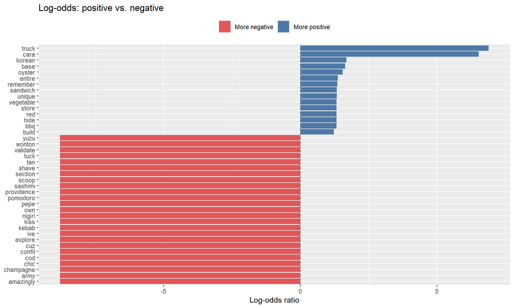

Figure 7: Log-odds ratio: words skewing positive vs. negative.

```r
bind_rows(
  log_odds |> slice_max(log_odds,n=15) |> mutate(group="More positive"),
  log_odds |> slice_min(log_odds,n=15) |> mutate(group="More negative")) |>
  ggplot(aes(x=log_odds, y=fct_reorder(word,log_odds), fill=group)) +
  geom_col() + geom_vline(xintercept=0, linetype="dashed", color="grey40") +
  scale_fill_manual(values=c("More positive"="#4E79A7","More negative"="#E15759")) +
  labs(title="Log-odds: positive vs. negative", x="Log-odds ratio",
       y=NULL, fill=NULL) + theme(legend.position="top")
```

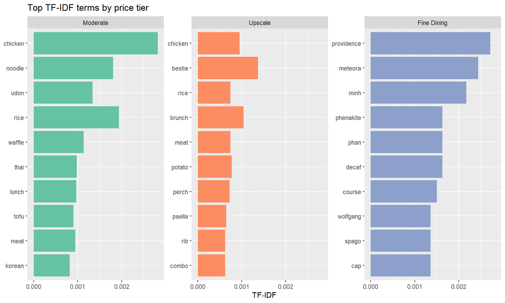

Figure 8: Top TF-IDF terms by price tier.

```r
tfidf_price |> group_by(price_tier) |> slice_max(tf_idf, n=10) |> ungroup() |>
  mutate(word=fct_reorder(word,tf_idf),
         price_tier=factor(price_tier,levels=c("Moderate","Upscale","Fine Dining"))) |>
  ggplot(aes(x=tf_idf, y=word, fill=price_tier)) + geom_col(show.legend=FALSE) +
  facet_wrap(~price_tier, scales="free_y") + scale_fill_brewer(palette="Set2") +
  labs(title="Top TF-IDF terms by price tier", x="TF-IDF", y=NULL)
```

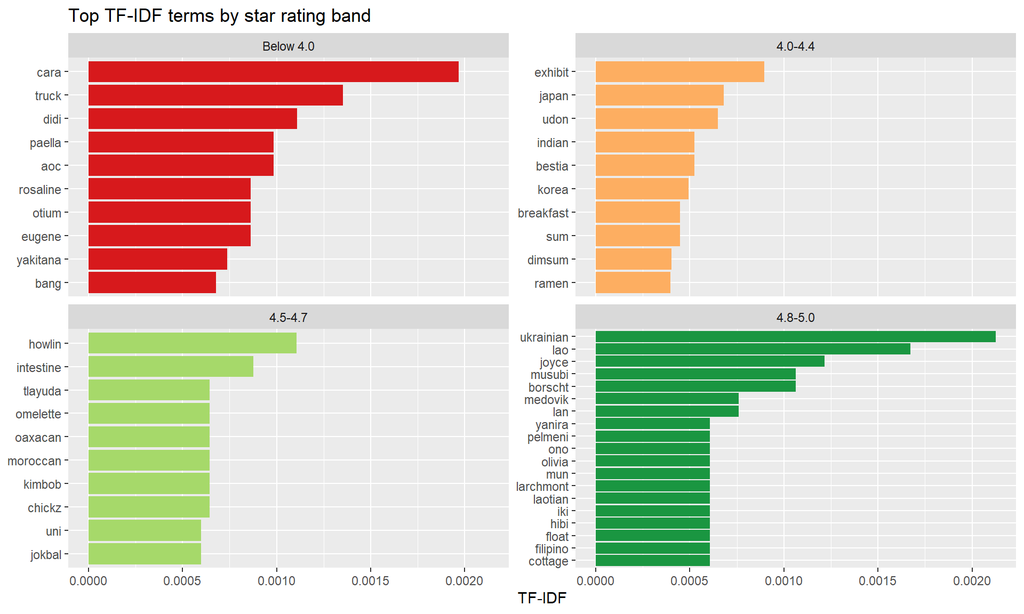

Figure 9: Top TF-IDF terms by star rating band.

```r
tfidf_rating |> group_by(rating_bin) |> slice_max(tf_idf, n=10) |> ungroup() |>
  mutate(word=fct_reorder(word,tf_idf),
         rating_bin=factor(rating_bin,levels=c("Below 4.0","4.0-4.4","4.5-4.7","4.8-5.0"))) |>
  ggplot(aes(x=tf_idf, y=word, fill=rating_bin)) + geom_col(show.legend=FALSE) +
  facet_wrap(~rating_bin, scales="free_y") + scale_fill_brewer(palette="RdYlGn",direction=1) +
  labs(title="Top TF-IDF terms by star rating band", x="TF-IDF", y=NULL)
```

# Step 5: Word embeddings

Word2Vec (skip-gram, 100 dims) and GloVe (100 dims) trained on the cleaned corpus. Document embeddings created by averaging token vectors per review.

```r
corpus <- reviews_clean$text_clean
set.seed(3847)
w2v_model      <- word2vec(x=corpus, type="skip-gram", dim=100,
                            window=5, iter=15, min_count=3, threads=2)
w2v_embeddings <- as.matrix(w2v_model)
tl  <- space_tokenizer(reviews_clean$text_clean)
it2 <- itoken(tl, progressbar=FALSE)
voc <- create_vocabulary(it2) |> prune_vocabulary(term_count_min=3)
v2  <- vocab_vectorizer(voc)
t2  <- create_tcm(it2, v2, skip_grams_window=5, progressbar=FALSE)
set.seed(3847)
glv <- GlobalVectors$new(rank=100, x_max=10, learning_rate=0.1)
wvm <- glv$fit_transform(t2, n_iter=15, convergence_tol=0.001, n_threads=2)
glove_embeddings <- wvm + t(glv$components)
get_nb <- function(model, term, n=4) {
  r <- tryCatch(predict(model,term,type="nearest",top_n=n+1),error=function(e)NULL)
  if(is.null(r)) return(NULL)
  r[[1]] |> filter(term2!=term) |> head(n) |> mutate(query=term)
}
review_tokens <- tokens_lemma |>
  filter(word %in% rownames(w2v_embeddings)) |>
  group_by(comment_id) |> summarise(words=list(unique(word)), .groups="drop")
doc_embeddings <- map(review_tokens$words,
  \(ws) colMeans(w2v_embeddings[ws,,drop=FALSE])) |> do.call(rbind, args=_)
rownames(doc_embeddings) <- review_tokens$comment_id
doc_meta <- review_tokens |> mutate(comment_id=as.integer(comment_id)) |>
  left_join(reviews_clean |> select(comment_id,sentiment_label,price_tier,StarRating),
            by="comment_id")
set.seed(3847)
umap_docs   <- umap(doc_embeddings, n_neighbors=15, min_dist=0.05)
umap_doc_df <- data.frame(x=umap_docs$layout[,1], y=umap_docs$layout[,2],
                           sentiment_label=doc_meta$sentiment_label,
                           price_tier=doc_meta$price_tier)
```

```r
map_dfr(c("food","service","friendly","wait","price","recommend"),
        get_nb, model=w2v_model, n=4) |>
  select(Query=query, Neighbor=term2, Similarity=similarity) |>
  mutate(Similarity=round(Similarity,3)) |>
  knitr::kable(caption="Word2Vec nearest neighbors")
```

Word2Vec nearest neighbors

| Query | Neighbor | Similarity |
| --- | --- | --- |
| food | speedy | 0.777 |
| food | goose | 0.754 |
| food | octavio | 0.751 |
| food | traveling | 0.751 |
| service | octavio | 0.784 |
| service | dawn | 0.781 |
| service | ryan | 0.781 |
| service | courteous | 0.773 |
| friendly | attentive | 0.866 |
| friendly | accommodating | 0.832 |
| friendly | helpful | 0.825 |
| friendly | courteous | 0.812 |
| wait | quoted | 0.720 |
| wait | weeknight | 0.705 |
| wait | excessive | 0.705 |
| wait | button | 0.699 |
| price | quantity | 0.771 |
| price | tag | 0.766 |
| price | unagi | 0.738 |
| price | prices | 0.737 |
| recommend | highly | 0.893 |
| recommend | suggest | 0.747 |
| recommend | recommended | 0.730 |
| recommend | sim | 0.677 |

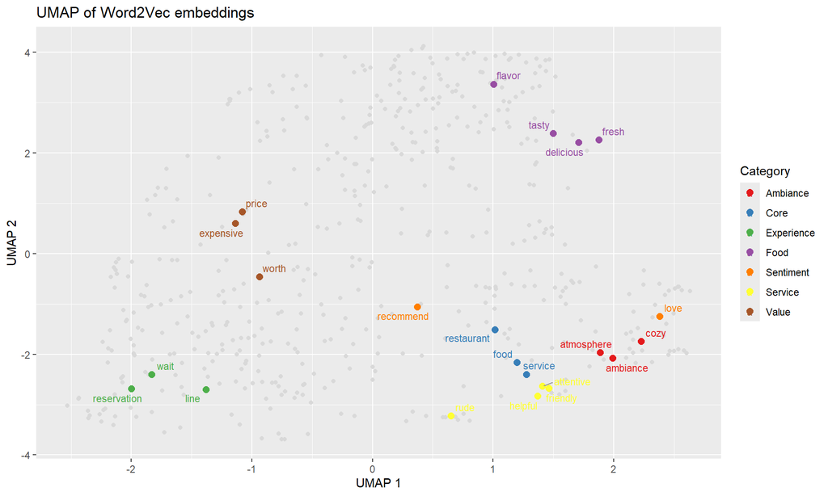

Figure 10: UMAP of Word2Vec word embeddings coloured by semantic category.

```r
fw  <- tokens_lemma |> count(word,sort=TRUE) |> filter(n>=30) |> pull(word)
fw  <- fw[fw %in% rownames(w2v_embeddings)]
set.seed(3847)
uw  <- umap(w2v_embeddings[fw,], n_neighbors=12, min_dist=0.1)
sc  <- tribble(~word,~cat,
  "food","Core","service","Core","restaurant","Core",
  "delicious","Food","tasty","Food","fresh","Food","flavor","Food",
  "friendly","Service","attentive","Service","helpful","Service","rude","Service",
  "wait","Experience","reservation","Experience","line","Experience",
  "atmosphere","Ambiance","ambiance","Ambiance","cozy","Ambiance",
  "price","Value","expensive","Value","worth","Value",
  "recommend","Sentiment","love","Sentiment","amazing","Sentiment")
ud <- data.frame(word=fw, x=uw$layout[,1], y=uw$layout[,2]) |>
  left_join(sc, by="word") |> mutate(cat=replace_na(cat,"Other"))
ggplot(ud, aes(x=x, y=y, color=cat)) +
  geom_point(data=filter(ud,cat=="Other"), color="grey85", size=1.5) +
  geom_point(data=filter(ud,cat!="Other"), size=2.5) +
  geom_text_repel(data=filter(ud,cat!="Other"), aes(label=word),
                  size=3, max.overlaps=30, segment.color="grey60") +
  scale_color_brewer(palette="Set1") +
  labs(title="UMAP of Word2Vec embeddings", x="UMAP 1", y="UMAP 2", color="Category")
```

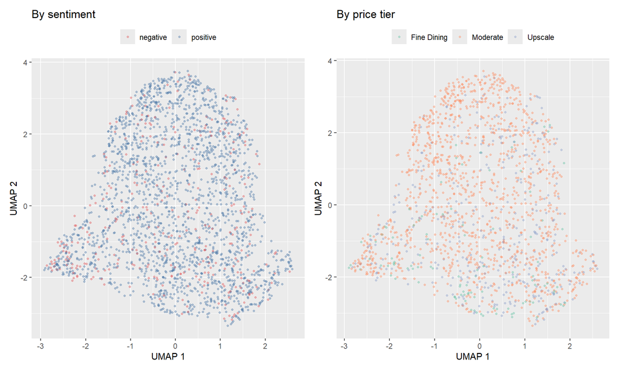

Figure 11: UMAP of document embeddings by sentiment (left) and price tier (right).

```r
ps <- ggplot(umap_doc_df, aes(x,y,color=sentiment_label)) +
  geom_point(alpha=0.4, size=0.9) +
  scale_color_manual(values=c(positive="#4E79A7",negative="#E15759")) +
  labs(title="By sentiment", x="UMAP 1", y="UMAP 2", color=NULL) +
  theme(legend.position="top")
pp <- umap_doc_df |> filter(price_tier!="Unknown") |>
  ggplot(aes(x,y,color=price_tier)) + geom_point(alpha=0.4, size=0.9) +
  scale_color_brewer(palette="Set2") +
  labs(title="By price tier", x="UMAP 1", y="UMAP 2", color=NULL) +
  theme(legend.position="top")
ps + pp
```